# ISLR Chapter 9

Alex Bayers

11/24/2018

### Exercise 1

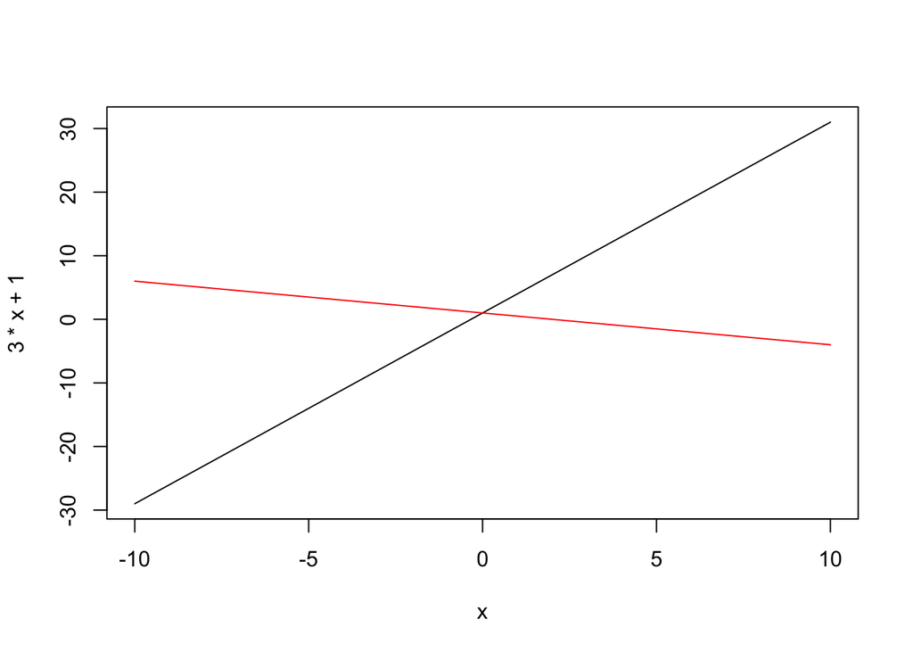

```r
curve(3*x + 1, from = -10, to =10, col = "black")
curve(-.5*x + 1, from = -10, to =10, col = "red", add = TRUE)
```

The area below the red line is the area for which -2 + x(1) + 2x(2) < 0. The area below the black line is the area for which 1 + 3x(1) - x(2) > 0.

### Exercise 2

##### A & B

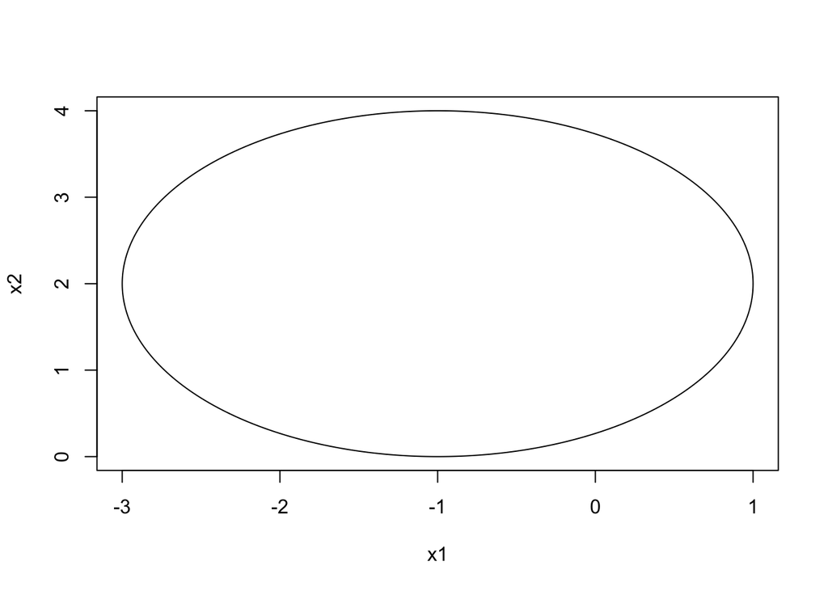

```r
plot(x=NULL, y = NULL, xlim = c(-3, 1), ylim = c(0, 4), xlab = "x1", ylab = "x2")
z <- seq(from = 0, to = 2*pi, by = .01)
lines(x = - 1 +2*cos(z), y = 2 + 2*sin(z))
```

This is a circle centered at (-1, 2) with a radius of 2. The area inside of and on the circle is the area is less than 4.

##### C

(0, 0) is blue. (-1, 1) is red. (2, 2) is blue. (3, 8) is blue.

##### D

This is simply an extended basis for the function.

### Exercise 3

##### A & B

```r
x1 <- c(3, 2, 4, 1, 2, 4, 4)
x2 <- c(4, 2, 4, 4, 1, 3, 1)
color <- c("red", "red", "red", "red", "blue", "blue", "blue")
print(data.frame(x1, x2, color))
```

```
##   x1 x2 color
## 1  3  4   red
## 2  2  2   red
## 3  4  4   red
## 4  1  4   red
## 5  2  1  blue
## 6  4  3  blue
## 7  4  1  blue
```

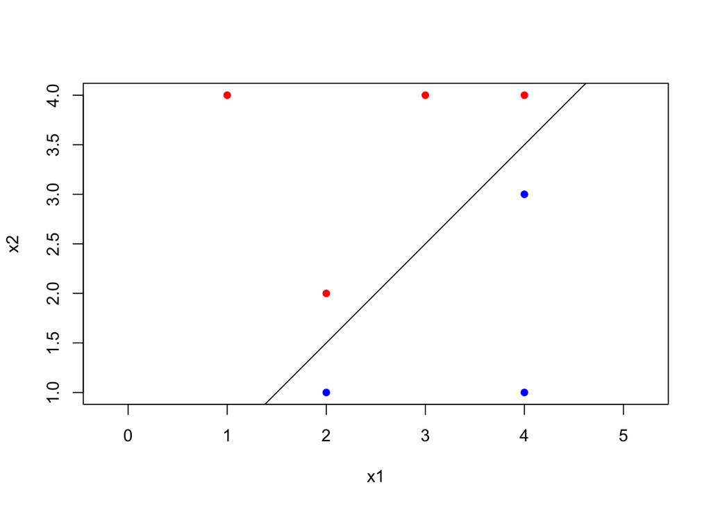

```r
plot(x = x1, y = x2, col = color, asp = 1, xlim = c(1, 4), ylim = c(1, 4), pch = 16)
x.line <- seq(from = 0, to = 5, by = 1)
lines(x = x.line, y = x.line - .5, col = "black")
```

The mathematical equation is $x_{1}-x_{2} - .5 = 0$

##### C

Our rule is to classify to red if $x_{1}-x_{2} - .5 < 0$, otherwise classify to blue.

##### D & E

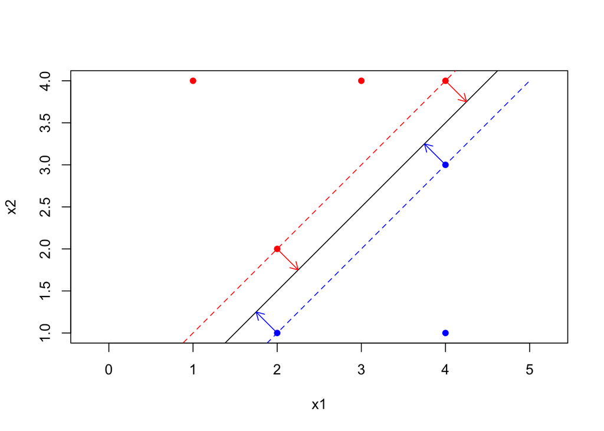

```r
plot(x = x1, y = x2, col = color, asp = 1, xlim = c(1, 4), ylim = c(1, 4), pch = 16)
lines(x = x.line, y = x.line - .5, col = "black")
lines(x = x.line, y = x.line - 1, col = "blue", lty = 2)
lines(x = x.line, y = x.line, col = "red", lty = 2)
arrows(x0 = 2, y0 = 1, x1 = 1.75, y1 = 1.25, col = "blue", length = .1)
arrows(x0 = 4, y0 = 3, x1 = 3.75, y1 = 3.25, col = "blue", length = .1)
arrows(x0 = 2, y0 = 2, x1 = 2.25, y1 = 1.75, col = "red", length = .1)
arrows(x0 = 4, y0 = 4, x1 = 4.25, y1 = 3.75, col = "red", length = .1)
```

```r
paste("The margin is", round((2*.25^2)^.5, 3))
```

```
## [1] "The margin is 0.354"
```

##### G

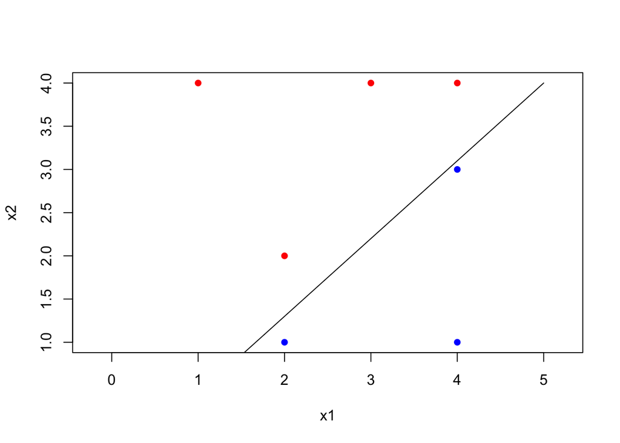

```r
plot(x = x1, y = x2, col = color, asp = 1, xlim = c(1, 4), ylim = c(1, 4), pch = 16)
lines(x = x.line, y = .9*x.line - .5, col = "black")
```

##### H

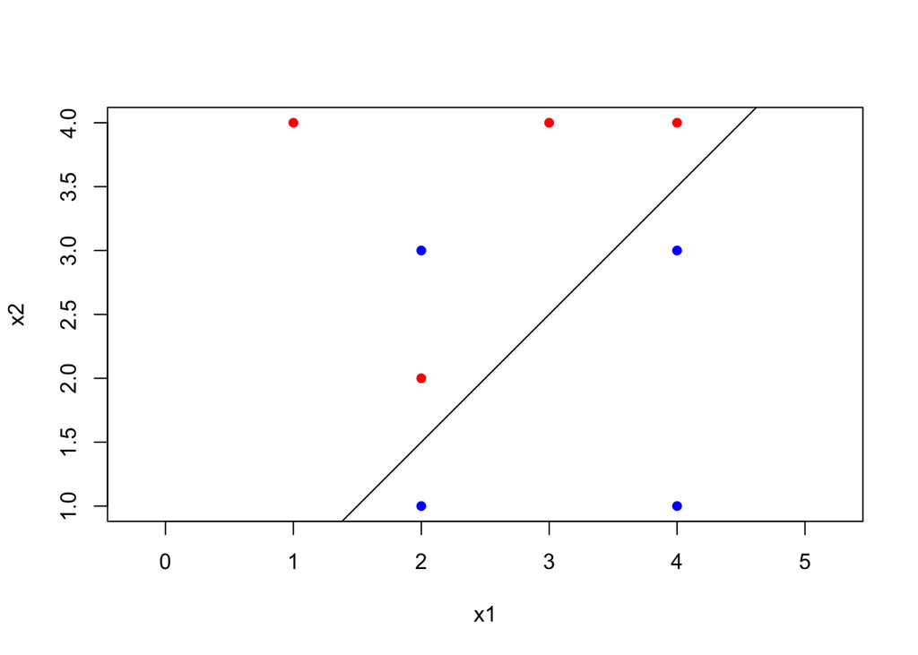

```r
x1 <- c(x1, 2)
x2 <- c(x2, 3)
color <- c(color, "blue")
plot(x = x1, y = x2, col = color, asp = 1, xlim = c(1, 4), ylim = c(1, 4), pch = 16)
lines(x = x.line, y = x.line - .5, col = "black")
```

### 4

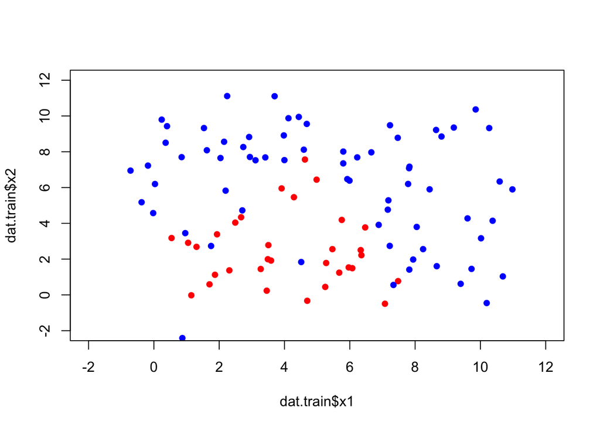

```r
library(e1071)
set.seed(1071)
x1 <- runif(200, min = 0, max = 10)
x2 <- runif(200, min = 0, max = 10)
color <- ifelse((x1 -4)^2 + (x2-3)^2 < 9, "red", "blue")
x1 <- x1 + rnorm(200, 0, 1)
x2 <- x2 + rnorm(200, 0, 1)
dat = data.frame(x1, x2, color = as.factor(color))
dat.train <- dat[1:100,]
dat.test <- dat[101:200,]
plot(dat.train$x1, dat.train$x2, xlim = c(-2, 12), ylim = c(-2, 12), col = as.character(dat.train$color), pch = 16)
```

Our generative model is we sample from a uniform distribution from 0 to 10, and everything in a circle of radius 3 around (4, 3) is red, otherwise its blue. We then perturb this with normal noise with a standard deviation of 1.

```r
#Fit a linear model
set.seed(341)
tune.out=tune(svm,color~.,data=dat.train,kernel="linear", ranges=list(cost=c(0.001, 0.01, 0.1, 1,5,10,100), scale = TRUE))
summary(tune.out)
```

```
##
## Parameter tuning of 'svm':
##
## - sampling method: 10-fold cross validation
##
## - best parameters:
##  cost scale
##     1  TRUE
##
## - best performance: 0.19
##
## - Detailed performance results:
##    cost scale error dispersion
## 1 1e-03  TRUE  0.32  0.1813529
## 2 1e-02  TRUE  0.32  0.1813529
## 3 1e-01  TRUE  0.19  0.1791957
## 4 1e+00  TRUE  0.19  0.1728840
## 5 5e+00  TRUE  0.19  0.1728840
## 6 1e+01  TRUE  0.19  0.1728840
## 7 1e+02  TRUE  0.19  0.1728840
```

```r
bestmod=tune.out$best.model
summary(bestmod)
```

```
##
## Call:
## best.tune(method = svm, train.x = color ~ ., data = dat.train,
##     ranges = list(cost = c(0.001, 0.01, 0.1, 1, 5, 10, 100),
##         scale = TRUE), kernel = "linear")
##
##
## Parameters:
##    SVM-Type:  C-classification
##  SVM-Kernel:  linear
##        cost:  1
##       gamma:  0.5
##
## Number of Support Vectors:  49
##
##  ( 25 24 )
##
##
## Number of Classes:  2
##
## Levels:
##  blue red
```

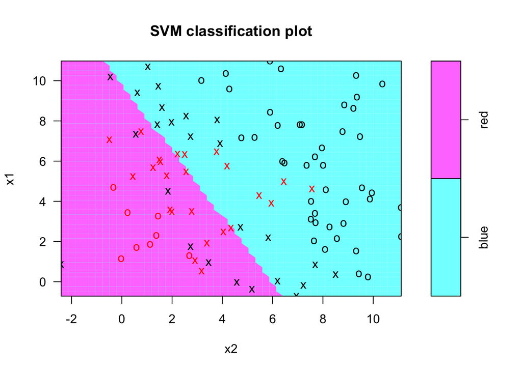

```r
plot(bestmod , dat.train)
```

```r
radial.out=tune(svm,color~.,data=dat.train,kernel="radial", ranges=list(cost=c(0.001, 0.01, 0.1, 1,5,10,100), gamma = c(0.001, 0.01, 0.1, 1,5,10,100), scale = TRUE))
summary(radial.out)
```

```
##
## Parameter tuning of 'svm':
##
## - sampling method: 10-fold cross validation
##
## - best parameters:
##  cost gamma scale
##    10   0.1  TRUE
##
## - best performance: 0.1
##
## - Detailed performance results:
##     cost gamma scale error dispersion
## 1  1e-03 1e-03  TRUE  0.32 0.10327956
## 2  1e-02 1e-03  TRUE  0.32 0.10327956
```

[output cut: 47 more lines]

```r
bestmod.radial=radial.out$best.model
summary(bestmod.radial)
```

```
##
## Call:
## best.tune(method = svm, train.x = color ~ ., data = dat.train,
##     ranges = list(cost = c(0.001, 0.01, 0.1, 1, 5, 10, 100),
##         gamma = c(0.001, 0.01, 0.1, 1, 5, 10, 100), scale = TRUE),
##     kernel = "radial")
##
##
## Parameters:
##    SVM-Type:  C-classification
##  SVM-Kernel:  radial
##        cost:  10
##       gamma:  0.1
##
## Number of Support Vectors:  34
##
##  ( 17 17 )
##
##
## Number of Classes:  2
##
## Levels:
##  blue red
```

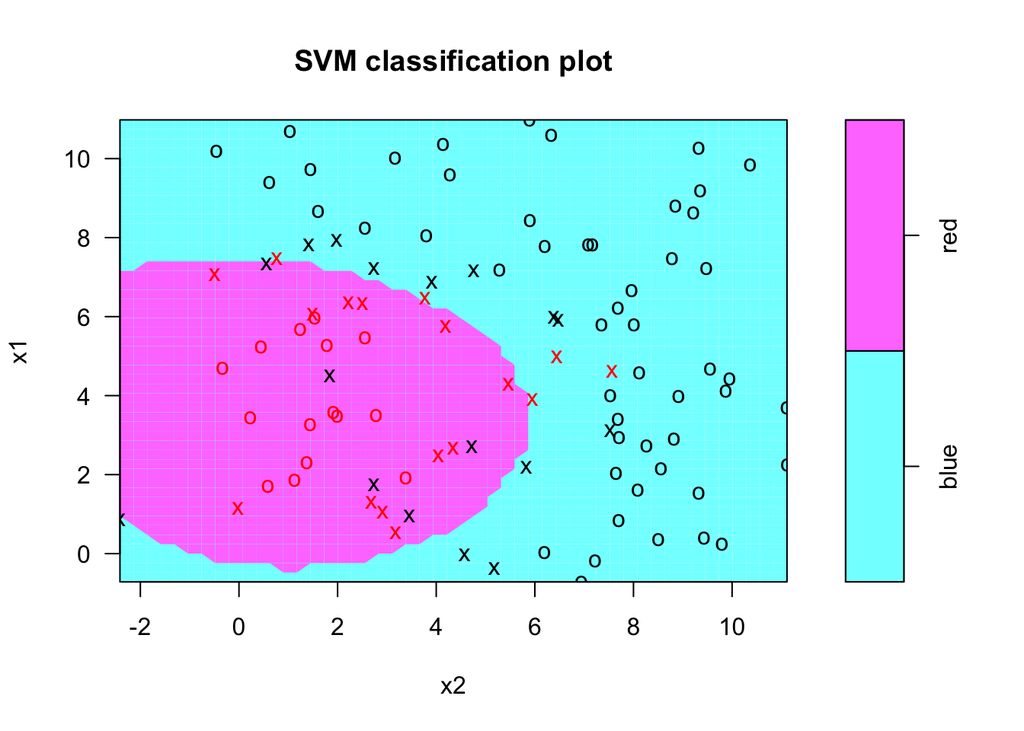

```r
plot(bestmod.radial , dat.train)
```

```r
poly.out=tune(svm,color~.,data=dat.train,kernel="polynomial", ranges=list(cost=c(0.001, 0.01, 0.1, 1,5,10,100), degree = c(2, 3, 4), scale = TRUE))
summary(poly.out)
```

```
##
## Parameter tuning of 'svm':
##
## - sampling method: 10-fold cross validation
##
## - best parameters:
##  cost degree scale
##     5      3  TRUE
##
## - best performance: 0.26
##
## - Detailed performance results:
##     cost degree scale error dispersion
## 1  1e-03      2  TRUE  0.32 0.12292726
## 2  1e-02      2  TRUE  0.32 0.12292726
## 3  1e-01      2  TRUE  0.32 0.12292726
## 4  1e+00      2  TRUE  0.33 0.12516656
## 5  5e+00      2  TRUE  0.36 0.14298407
## 6  1e+01      2  TRUE  0.35 0.14337209
## 7  1e+02      2  TRUE  0.38 0.16193277
## 8  1e-03      3  TRUE  0.32 0.12292726
## 9  1e-02      3  TRUE  0.32 0.12292726
## 10 1e-01      3  TRUE  0.33 0.12516656
## 11 1e+00      3  TRUE  0.27 0.08232726
## 12 5e+00      3  TRUE  0.26 0.09660918
## 13 1e+01      3  TRUE  0.26 0.09660918
## 14 1e+02      3  TRUE  0.26 0.06992059
## 15 1e-03      4  TRUE  0.32 0.12292726
## 16 1e-02      4  TRUE  0.32 0.12292726
## 17 1e-01      4  TRUE  0.33 0.12516656
## 18 1e+00      4  TRUE  0.34 0.13498971
## 19 5e+00      4  TRUE  0.34 0.13498971
## 20 1e+01      4  TRUE  0.34 0.13498971
## 21 1e+02      4  TRUE  0.42 0.11352924
```

```r
bestmod.poly=poly.out$best.model
summary(bestmod.poly)
```

```
##
## Call:
## best.tune(method = svm, train.x = color ~ ., data = dat.train,
##     ranges = list(cost = c(0.001, 0.01, 0.1, 1, 5, 10, 100),
##         degree = c(2, 3, 4), scale = TRUE), kernel = "polynomial")
##
##
## Parameters:
##    SVM-Type:  C-classification
##  SVM-Kernel:  polynomial
##        cost:  5
##      degree:  3
##       gamma:  0.5
##      coef.0:  0
##
## Number of Support Vectors:  60
##
##  ( 31 29 )
##
##
## Number of Classes:  2
##
## Levels:
##  blue red
```

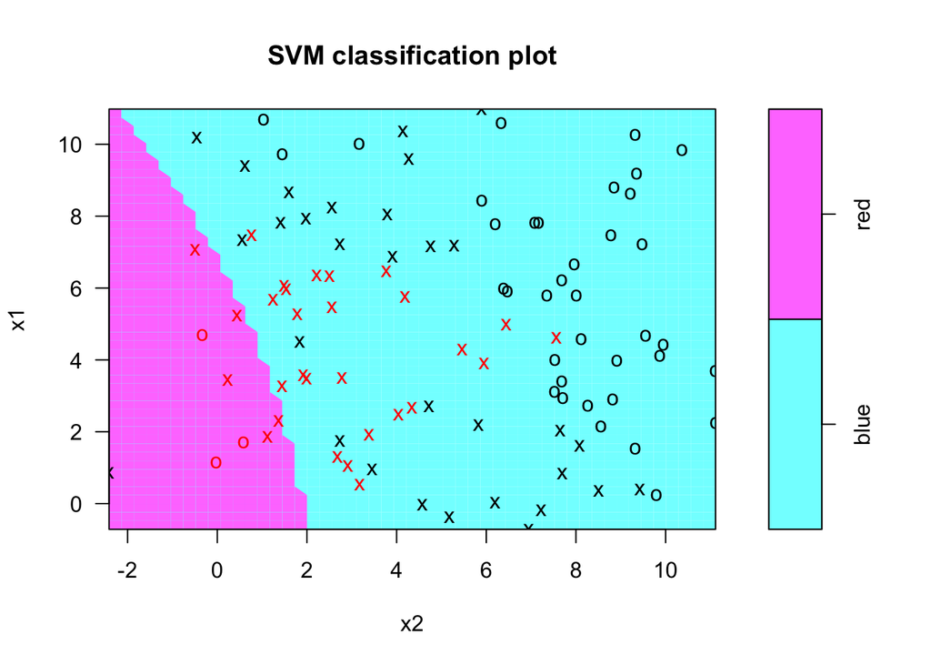

```r
plot(bestmod.poly , dat.train)
```

```r
linearpredict <- predict(bestmod, newdata = dat.test)
radialpredict <- predict(bestmod.radial, newdata = dat.test)
polypredict <- predict(bestmod.poly, newdata = dat.test)

lineartable <- table(dat.test$color, linearpredict)
radialtable <- table(dat.test$color, radialpredict)
polytable <- table(dat.test$color, polypredict)

print(lineartable)
```

```
##       linearpredict
##        blue red
##   blue   56  12
##   red    10  22
```

```r
print(radialtable)
```

```
##       radialpredict
##        blue red
##   blue   61   7
##   red     2  30
```

```r
print(polytable)
```

```
##       polypredict
##        blue red
##   blue   63   5
##   red    29   3
```

```r
#TODO - build cross validation models for polynomial and radial basis kernels, compare test set error.
```

In the training set, a linear kernel has an error rate of 19% using the optimal parameters. Using a polynomial model, we have an error rate of 26% using a cubic kernel. Using a radial model, we obtain an error rate of only 10%.

The test set confirms this data quite well. The linear model has an error rate of 22%, the polynomial 34%, and the radial 9%.

### Exercise 5

##### A & B

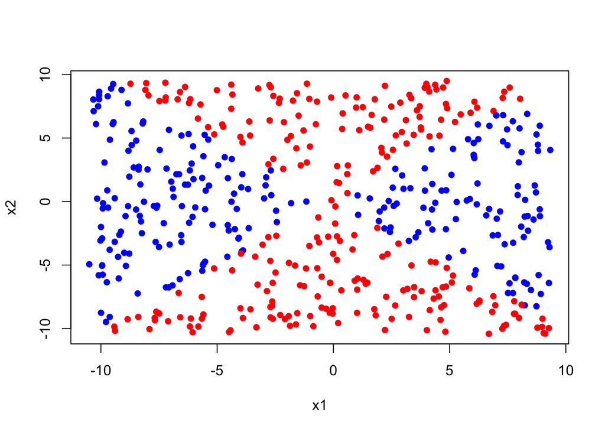

```r
set.seed(197)
x1=runif(500, min = -10, max = 10)-0.5
x2=runif(500, min = -10, max = 10)-0.5
y=1*(x1^2-x2^2 > 0)
color = ifelse(y == 1, "blue", "red")
ex5.train <- data.frame(x1, x2, y, color)
plot(x=x1, y = x2, col=color, pch = 16)
```

##### C

```r
logistic.model <- glm(y ~ x1 + x2, data = ex5.train)
summary(logistic.model)
```

```
##
## Call:
## glm(formula = y ~ x1 + x2, data = ex5.train)
##
## Deviance Residuals:
##     Min       1Q   Median       3Q      Max
## -0.6372  -0.4769  -0.3370   0.4825   0.6684
##
## Coefficients:
##              Estimate Std. Error t value Pr(>|t|)
## (Intercept)  0.481183   0.022363  21.517  < 2e-16 ***
## x1          -0.011226   0.003779  -2.970  0.00312 **
## x2           0.006260   0.003709   1.688  0.09208 .
## ---
## Signif. codes:  0 '***' 0.001 '**' 0.01 '*' 0.05 '.' 0.1 ' ' 1
##
## (Dispersion parameter for gaussian family taken to be 0.2451061)
##
##     Null deviance: 124.87  on 499  degrees of freedom
## Residual deviance: 121.82  on 497  degrees of freedom
## AIC: 720.9
##
## Number of Fisher Scoring iterations: 2
```

##### D

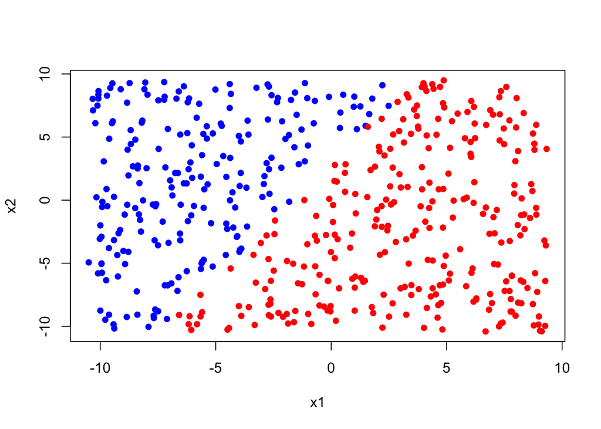

```r
pred.y <- predict(logistic.model, newdata = ex5.train, type = "response")
color.pred = ifelse(pred.y > .5, "blue", "red")
plot(x=x1, y = x2, col=color.pred, pch = 16)
```

##### E

```r
logistic.model.exp  <- glm(y ~ I(x1^2) + I(x2^2), data = ex5.train)
summary(logistic.model.exp)
```

```
##
## Call:
## glm(formula = y ~ I(x1^2) + I(x2^2), data = ex5.train)
##
## Deviance Residuals:
##      Min        1Q    Median        3Q       Max
## -0.53592  -0.25435   0.00585   0.27420   0.52931
##
## Coefficients:
##               Estimate Std. Error t value Pr(>|t|)
## (Intercept)  0.5359602  0.0256687   20.88   <2e-16 ***
## I(x1^2)      0.0086312  0.0004452   19.39   <2e-16 ***
## I(x2^2)     -0.0097518  0.0004344  -22.45   <2e-16 ***
## ---
## Signif. codes:  0 '***' 0.001 '**' 0.01 '*' 0.05 '.' 0.1 ' ' 1
##
## (Dispersion parameter for gaussian family taken to be 0.09215231)
##
##     Null deviance: 124.87  on 499  degrees of freedom
## Residual deviance:  45.80  on 497  degrees of freedom
## AIC: 231.77
##
## Number of Fisher Scoring iterations: 2
```

##### F

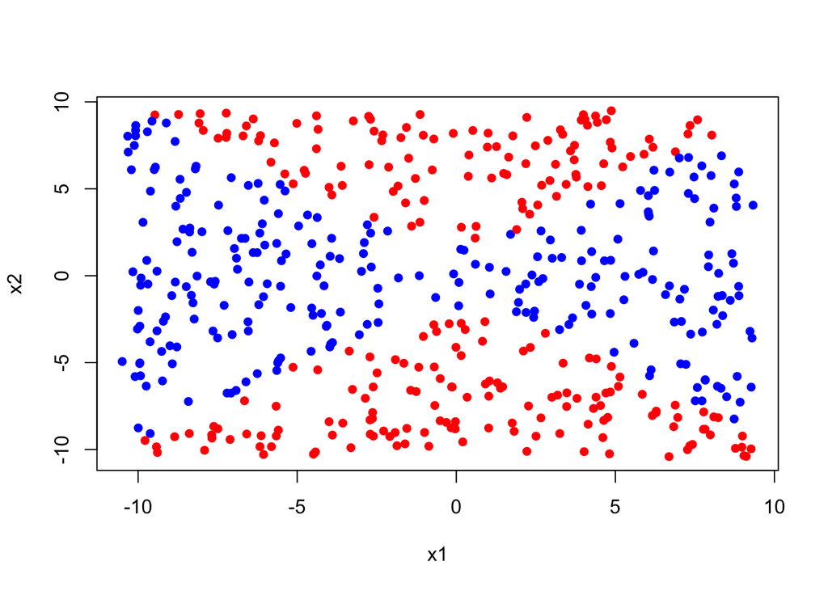

```r
pred.exp <- predict(logistic.model.exp, newdata = ex5.train, type = "response")
color.exp = ifelse(pred.exp > .5, "blue", "red")
plot(x=x1, y = x2, col=color.exp, pch = 16)
```

##### G

```r
tune.linear=tune(svm,y~.-color,data=ex5.train,kernel="linear", ranges=list(cost=c(0.001, 0.01, 0.1, 1,5,10,100), scale = TRUE))
bestmodel.linear <- tune.linear$best.model
summary(bestmodel.linear)
```

```
##
## Call:
## best.tune(method = svm, train.x = y ~ . - color, data = ex5.train,
##     ranges = list(cost = c(0.001, 0.01, 0.1, 1, 5, 10, 100),
##         scale = TRUE), kernel = "linear")
##
##
## Parameters:
##    SVM-Type:  eps-regression
##  SVM-Kernel:  linear
##        cost:  0.01
##       gamma:  0.5
##     epsilon:  0.1
##
##
## Number of Support Vectors:  487
```

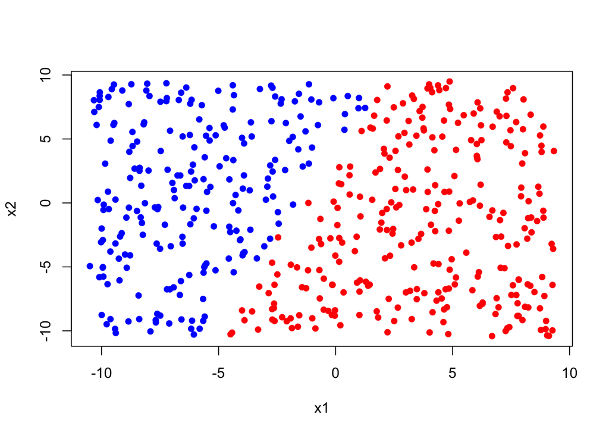

```r
pred.linear <- predict(bestmodel.linear, newdata = ex5.train, type = "response")
color.linsvm = ifelse(pred.linear > .5, "blue", "red")
plot(x=x1, y = x2, col=color.linsvm, pch = 16)
```

##### H

```r
tune.quad=tune(svm,y~.-color,data=ex5.train,kernel="polynomial", ranges=list(cost=c(0.001, 0.01, 0.1, 1,5,10,100), scale = TRUE, degree = c(2)))
bestmodel.quadratic <- tune.quad$best.model
summary(bestmodel.quadratic)
```

```
##
## Call:
## best.tune(method = svm, train.x = y ~ . - color, data = ex5.train,
##     ranges = list(cost = c(0.001, 0.01, 0.1, 1, 5, 10, 100),
##         scale = TRUE, degree = c(2)), kernel = "polynomial")
##
##
## Parameters:
##    SVM-Type:  eps-regression
##  SVM-Kernel:  polynomial
##        cost:  0.1
##      degree:  2
##       gamma:  0.5
##      coef.0:  0
##     epsilon:  0.1
##
##
## Number of Support Vectors:  450
```

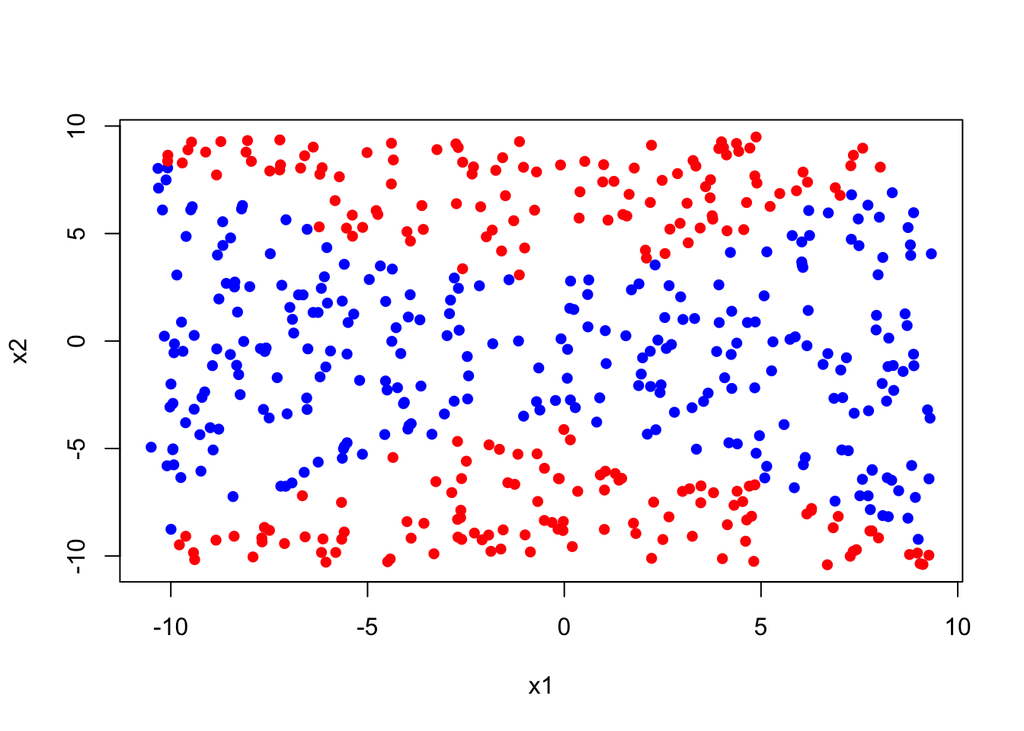

```r
pred.quad <- predict(bestmodel.quadratic, newdata = ex5.train, type = "response")
color.linsvm = ifelse(pred.quad > .5, "blue", "red")
plot(x=x1, y = x2, col=color.linsvm, pch = 16)
```

##### I

The linear kernel is unable to capture the nonlinearities in the data. By comparison, the quadratic model is. However, despite that, the expanded basis for logistic regression does a better job capturing the nonlinearities than the quadratic svm.

### Exercise 6

##### A

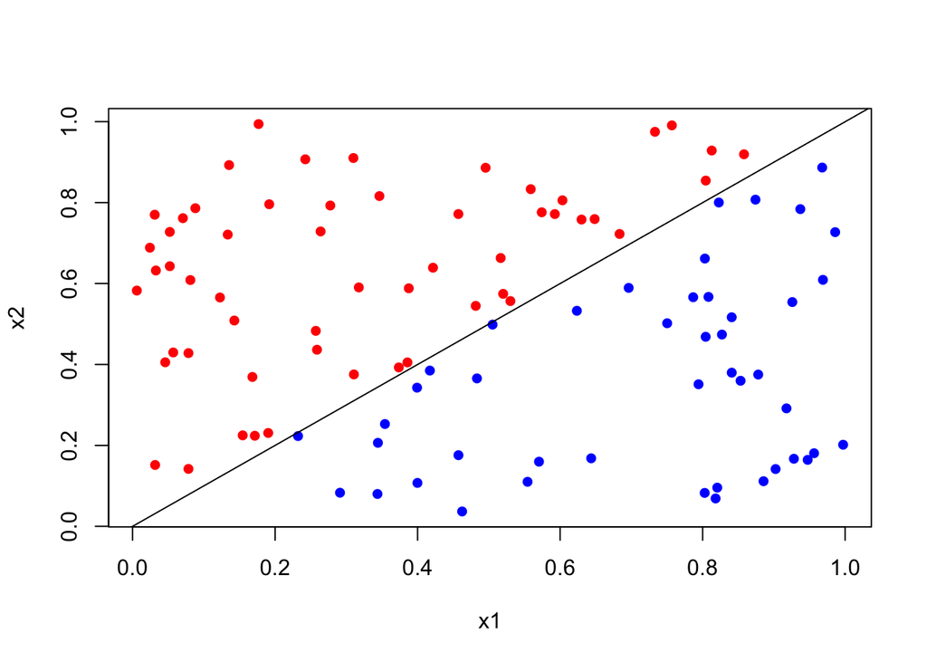

```r
x1=runif(100)
x2=runif(100)
y <- ifelse(x1 > x2, 1, 0)
color <- ifelse(y==1, "blue", "red")
plot(x1, x2, col = color, pch = 16)
abline(a = 0, b =1, col = "black")
```

```r
my.frame <- data.frame(x1, x2, y)
```

##### B

```r
tune.linear <- tune(svm, y ~., data=my.frame,kernel="linear", ranges=list(cost=c(0.001, 0.01, 0.1, 1,5,10,100)))
summary(tune.linear)
```

```
##
## Parameter tuning of 'svm':
##
## - sampling method: 10-fold cross validation
##
## - best parameters:
##  cost
##   0.1
##
## - best performance: 0.1076089
##
## - Detailed performance results:
##    cost     error dispersion
## 1 1e-03 0.3539311 0.13244375
## 2 1e-02 0.1088593 0.03282641
## 3 1e-01 0.1076089 0.04161664
## 4 1e+00 0.1099256 0.04486416
## 5 5e+00 0.1104792 0.04469918
## 6 1e+01 0.1105218 0.04471735
## 7 1e+02 0.1106461 0.04464918
```

##### C

```r
x1.test=runif(1000)
x2.test=runif(1000)
y.test <- ifelse(x1.test > x2.test, 1, 0)
new.frame <- data.frame (x1 = x1.test, x2 = x2.test, y = y.test)
test.matrix <- as.matrix(c(0.005, 0.01, 0.1, 1,5,10,100))
for (i in 1:length(test.matrix)){
  svm.model <- svm(y ~., data = my.frame, kernel = "linear", cost = test.matrix[i])
  svm.pred <- predict(svm.model, newdata = new.frame)
  svm.cat <- ifelse(svm.pred > 0.5, 1, 0)
  svm.table <- table(y.test, svm.cat)
  cat.error <- (svm.table[2,1] + svm.table[1, 2])/1000
  print(cat.error)
}
```

```
## [1] 0.404
## [1] 0.079
## [1] 0.064
## [1] 0.097
## [1] 0.09
## [1] 0.09
## [1] 0.09
```

.1 minimizes the cost.

### Exercise 7

##### A & B

```r
library(ISLR)
median.mpg <- median(Auto$mpg)
Auto$MPGBin <- ifelse(Auto$mpg > median.mpg, 1, 0)
tune.linear=tune(svm,MPGBin~.-mpg,data=Auto,kernel="linear", ranges=list(cost=c(0.001, 0.01, 0.1, 1,5,10,100), scale = TRUE))
summary(tune.linear)
```

```
##
## Parameter tuning of 'svm':
##
## - sampling method: 10-fold cross validation
##
## - best parameters:
##  cost scale
##     1  TRUE
##
## - best performance: 0.09650698
##
## - Detailed performance results:
##    cost scale      error dispersion
## 1 1e-03  TRUE 0.10903767 0.01725251
## 2 1e-02  TRUE 0.10443117 0.02198843
## 3 1e-01  TRUE 0.10229931 0.02726701
## 4 1e+00  TRUE 0.09650698 0.02227025
## 5 5e+00  TRUE 0.10225144 0.02354368
## 6 1e+01  TRUE 0.10720514 0.02507701
## 7 1e+02  TRUE 0.12293528 0.03190569
```

Error is minimized with a cost of 1.

### Exercise 8

##### A

```r
set.seed(1986)
train <- sample(1:(dim(OJ)[1]), 800)
OJ.train <- OJ[train,]
OJ.test <- OJ[-train,]
```

##### B & C

```r
OJ.model <- svm(Purchase ~., data = OJ.train, kernel = "linear", cost = 0.01)
summary(OJ.model)
```

```
##
## Call:
## svm(formula = Purchase ~ ., data = OJ.train, kernel = "linear",
##     cost = 0.01)
##
##
## Parameters:
##    SVM-Type:  C-classification
##  SVM-Kernel:  linear
##        cost:  0.01
##       gamma:  0.05555556
##
## Number of Support Vectors:  432
##
##  ( 217 215 )
##
##
## Number of Classes:  2
##
## Levels:
##  CH MM
```

```r
train.pred <- predict(OJ.model, newdata = OJ.train)
sum(train.pred==OJ.train$Purchase)/800
```

```
## [1] 0.83375
```

```r
test.pred <- predict(OJ.model, newdata = OJ.test)
sum(test.pred==OJ.test$Purchase)/270
```

```
## [1] 0.8296296
```

##### D & E

```r
set.seed(347)
tune.linear <- tune(svm, Purchase ~., data=OJ.train,kernel="linear", ranges=list(cost=c(0.01, 0.1, 1,5,10)))
summary(tune.linear)
```

```
##
## Parameter tuning of 'svm':
##
## - sampling method: 10-fold cross validation
##
## - best parameters:
##  cost
##     1
##
## - best performance: 0.1675
##
## - Detailed performance results:
##    cost   error dispersion
## 1  0.01 0.17500 0.03280837
## 2  0.10 0.16875 0.04050463
## 3  1.00 0.16750 0.04216370
## 4  5.00 0.17375 0.03928617
## 5 10.00 0.17250 0.03809710
```

```r
test.best <- predict(tune.linear$best.model, newdata = OJ.test)
sum(test.best==OJ.test$Purchase)/270
```

```
## [1] 0.8259259
```

##### F

```r
set.seed(348)
tune.radial <- tune(svm, Purchase ~., data=OJ.train,kernel="radial", ranges=list(cost=c(0.01, 0.1, 1,5,10)))
summary(tune.radial)
```

```
##
## Parameter tuning of 'svm':
##
## - sampling method: 10-fold cross validation
##
## - best parameters:
##  cost
##     1
##
## - best performance: 0.16875
##
## - Detailed performance results:
##    cost   error dispersion
## 1  0.01 0.39000 0.03944053
## 2  0.10 0.18625 0.08216895
## 3  1.00 0.16875 0.06515207
## 4  5.00 0.17250 0.06230525
## 5 10.00 0.16875 0.05690208
```

```r
radial.best <- predict(tune.radial$best.model, newdata = OJ.test)
sum(radial.best==OJ.test$Purchase)/270
```

```
## [1] 0.8
```

##### F

```r
set.seed(348)
tune.poly <- tune(svm, Purchase ~., data=OJ.train,kernel="poly", ranges=list(cost=c(0.01, 0.1, 1,5,10), degree = c(2)))
summary(tune.poly)
```

```
##
## Parameter tuning of 'svm':
##
## - sampling method: 10-fold cross validation
##
## - best parameters:
##  cost degree
##     5      2
##
## - best performance: 0.1725
##
## - Detailed performance results:
##    cost degree   error dispersion
## 1  0.01      2 0.39000 0.03944053
## 2  0.10      2 0.32125 0.05138701
## 3  1.00      2 0.19375 0.05929271
## 4  5.00      2 0.17250 0.06790516
## 5 10.00      2 0.17500 0.07120003
```

```r
poly.best <- predict(tune.poly$best.model, newdata = OJ.test)
sum(poly.best==OJ.test$Purchase)/270
```

```
## [1] 0.8037037
```